# Multiple Regression analysis

JB

2017년 9월 5일

### **사용 데이터**

iphone 전체 기종에서 팔려진 데이터를 관찰.  
(총 14845개 관측치, 19개 변수 - 데이터개요 참고.)

#### 다중회귀분석 결과

```
##      (Intercept)   KRNAME아이폰 4  KRNAME아이폰 4S   KRNAME아이폰 5
##       152731.530        29056.092        40198.857        66603.539
##  KRNAME아이폰 5C  KRNAME아이폰 5S   KRNAME아이폰 6  KRNAME아이폰 6+
##        73136.843       118069.879       194097.533       272370.951
##  KRNAME아이폰 6S KRNAME아이폰 6S+   KRNAME아이폰 7  KRNAME아이폰 7+
##       309496.899       381625.567       543485.437       759630.591
##  KRNAME아이폰 SE           GB16GB          GB256GB           GB32GB
##       216073.573      -111696.742       179405.070      -100366.326
##           GB64GB            GB8GB CONDITIONS미사용     CONDITIONS상
##       -37964.682      -114386.605       118478.291        -8290.722
##     CONDITIONS중     CONDITIONS하  CHANGES유심기변  CHANGES확정기변
##       -32884.932      -102699.698        19448.216         5800.751
```

```
##                        0.5 %    99.5 %
## (Intercept)       -37461.636 342924.70
## KRNAME아이폰 4    -99920.915 158033.10
## KRNAME아이폰 4S   -93731.926 174129.64
## KRNAME아이폰 5    -50573.158 183780.24
## KRNAME아이폰 5C   -61411.929 207685.62
## KRNAME아이폰 5S     2529.318 233610.44
## KRNAME아이폰 6     79199.629 308995.44
## KRNAME아이폰 6+   156859.833 387882.07
## KRNAME아이폰 6S   194338.940 424654.86
## KRNAME아이폰 6S+  266010.484 497240.65
## KRNAME아이폰 7    428375.511 658595.36
## KRNAME아이폰 7+   644111.612 875149.57
## KRNAME아이폰 SE   100488.188 331658.96
## GB16GB           -130305.258 -93088.23
## GB256GB           140740.666 218069.47
## GB32GB           -115116.516 -85616.14
## GB64GB            -56616.369 -19312.99
## GB8GB            -289926.209  61153.00
## CONDITIONS미사용  -32002.044 268958.63
## CONDITIONS상     -158500.550 141919.11
## CONDITIONS중     -183132.313 117362.45
## CONDITIONS하     -254186.553  48787.16
## CHANGES유심기변    -3248.873  42145.30
## CHANGES확정기변   -15204.933  26806.43
```

### 예시- iphone 전체데이터

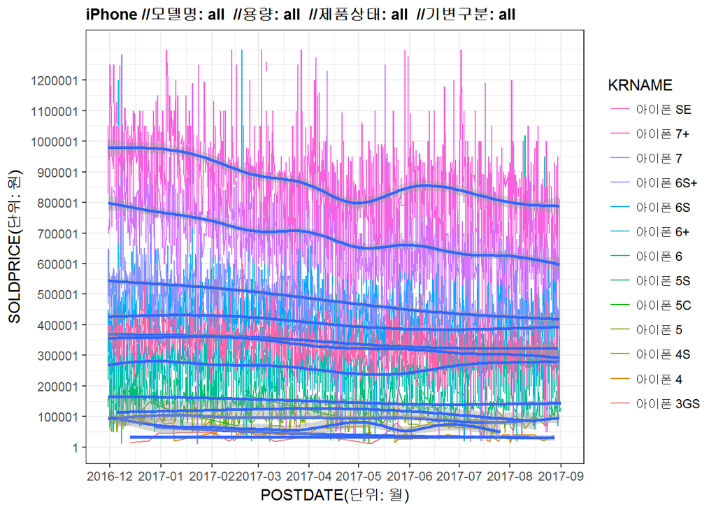

### 예시1

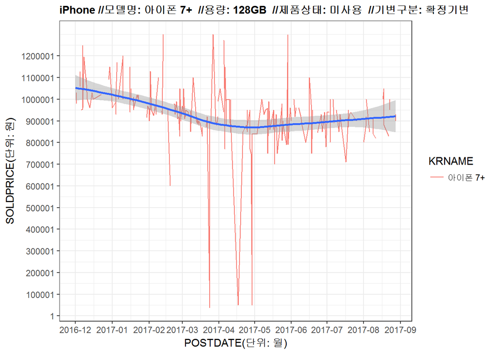

```
## [1] "모델명: 아이폰 7+  //용량: 128GB  //제품상태: 미사용  //기변구분: 확정기변"
## [1] "예상 평균가:  1037000 원"
## [1] "하위25% 가격: 912000 원 // 상위25% 가격:  1162000 원"
```

### 예시2

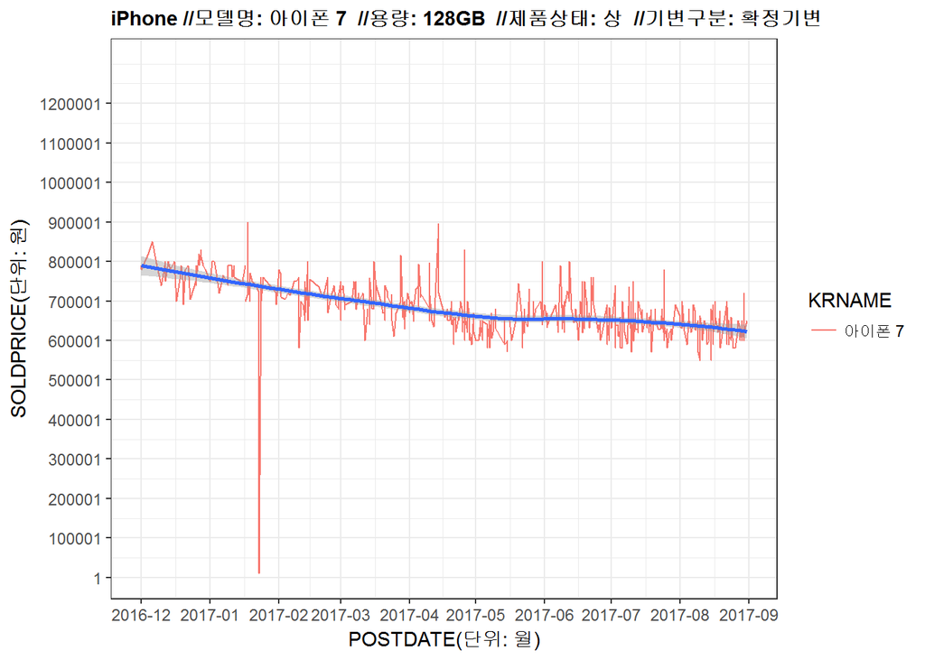

```
## [1] "모델명: 아이폰 7  //용량: 128GB  //제품상태: 상  //기변구분: 확정기변"
## [1] "예상 평균가:  694000 원"
## [1] "하위25% 가격: 569000 원 // 상위25% 가격:  818000 원"
```

### 예시3

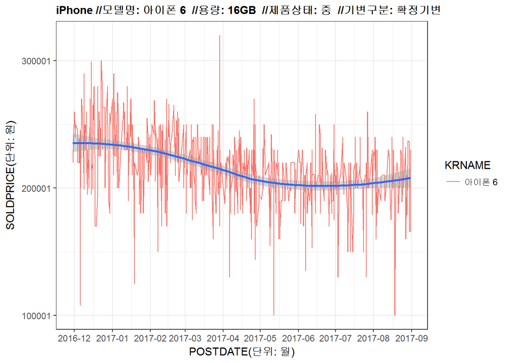

```
## [1] "모델명: 아이폰 6  //용량: 16GB  //제품상태: 중  //기변구분: 확정기변"
## [1] "예상 평균가:  208000 원"
## [1] "하위25% 가격: 78000 원 // 상위25% 가격:  338000 원"
```

### 예시4

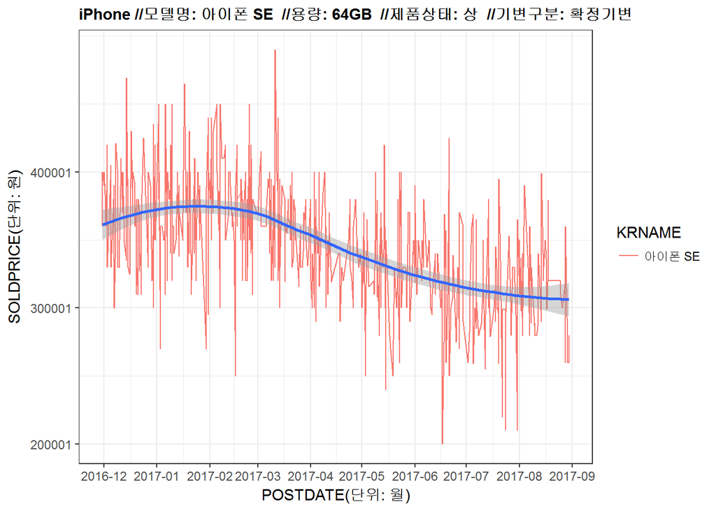

```
## [1] "모델명: 아이폰 SE  //용량: 64GB  //제품상태: 상  //기변구분: 확정기변"
## [1] "예상 평균가:  328000 원"
## [1] "하위25% 가격: 199000 원 // 상위25% 가격:  458000 원"
```

### 예시5

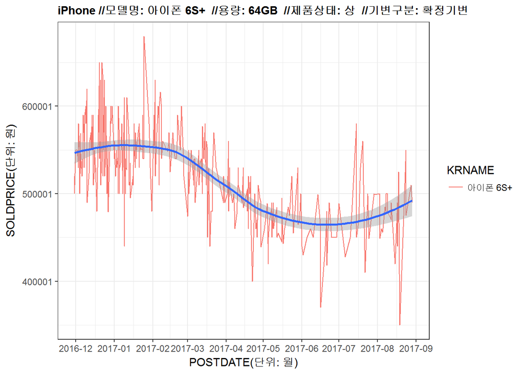

```
## [1] "모델명: 아이폰 6S+  //용량: 64GB  //제품상태: 상  //기변구분: 확정기변"
## [1] "예상 평균가:  494000 원"
## [1] "하위25% 가격: 364000 원 // 상위25% 가격:  624000 원"
```

## **오류분석과정**

```
## [1] 0.9919843
```

```
## Analysis of Variance Table
##
## Model 1: SOLDPRICE ~ KRNAME + GB + CONDITIONS + CHANGES
## Model 2: SOLDPRICE ~ POSTDATE + GB + KRNAME + CONTRACT + GUARANTEE + CHANGES +
##     CONDITIONS + COMPONENT + reldate + relprice + genGap + DATEGAP +
##     PRICERATE
##   Res.Df        RSS Df  Sum of Sq     F    Pr(>F)
## 1  14821 4.5251e+14
## 2  14810 1.2035e+13 11 4.4048e+14 49275 < 2.2e-16 ***
## ---
## Signif. codes:  0 '***' 0.001 '**' 0.01 '*' 0.05 '.' 0.1 ' ' 1
```

```
##   POSTDATE         GB     KRNAME  GUARANTEE    CHANGES CONDITIONS
##      FALSE      FALSE      FALSE      FALSE      FALSE      FALSE
##  COMPONENT    reldate     genGap  PRICERATE
##      FALSE       TRUE       TRUE      FALSE
```

### model.both(stepAIC로 추려내진 모델)

summary에서 Multiple R-squared가 0.9919로 독립변수들이 종속변수들을 99.19%만큼 설명할 수 있다.  
vif결과에서 GVIF^(1/(2*Df))의 값이 2가 넘어가는  
reldate(출시된 날짜로부터 판매게시글 올리는 날짜수), genGap(최신 모델과 이전 모델 사이의 날짜수)를 제외하고  
다중공선성(변수간의 상관관계정도)가 안정적으로 독립됨을 얘기한다.

```
## [1] 0.6988543
```

```
## Analysis of Variance Table
##
## Model 1: SOLDPRICE ~ KRNAME + GB + CONDITIONS + CHANGES
## Model 2: SOLDPRICE ~ POSTDATE + GB + KRNAME + CONTRACT + GUARANTEE + CHANGES +
##     CONDITIONS + COMPONENT + reldate + relprice + genGap + DATEGAP +
##     PRICERATE
##   Res.Df        RSS Df  Sum of Sq     F    Pr(>F)
## 1  14821 4.5251e+14
## 2  14810 1.2035e+13 11 4.4048e+14 49275 < 2.2e-16 ***
## ---
## Signif. codes:  0 '***' 0.001 '**' 0.01 '*' 0.05 '.' 0.1 ' ' 1
```

```
##     KRNAME         GB CONDITIONS    CHANGES
##      FALSE      FALSE      FALSE      FALSE
```

### 사용자 편의를 위한 임의모델분석

summary에서 Multiple R-squared가 0.6988543 독립변수들이 종속변수들을 약 69.88%만큼 설명할 수 있다.  
하지만 전체 모델과 사용자임의 모델간에 F-test 결과, 사용자 임의모델은 유의하지않다고 해석할수 있다.  
vif결과에서 GVIF^(1/(2*Df))의 값이 2가 넘어가는 변수가 존재하지않으므로,  
다중공선성(변수간의 상관관계정도)가 안정적으로 독립됨을 얘기한다.

```
##
##  studentized Breusch-Pagan test
##
## data:  modelp.short
## BP = 550.16, df = 23, p-value < 2.2e-16
```

```
##
##  Durbin-Watson test
##
## data:  modelp.short
## DW = 1.7287, p-value < 2.2e-16
## alternative hypothesis: true autocorrelation is greater than 0
```

```
##
##  Shapiro-Wilk normality test
##
## data:  sample(modelp.short$residuals, 5000)
## W = 0.40802, p-value < 2.2e-16
```

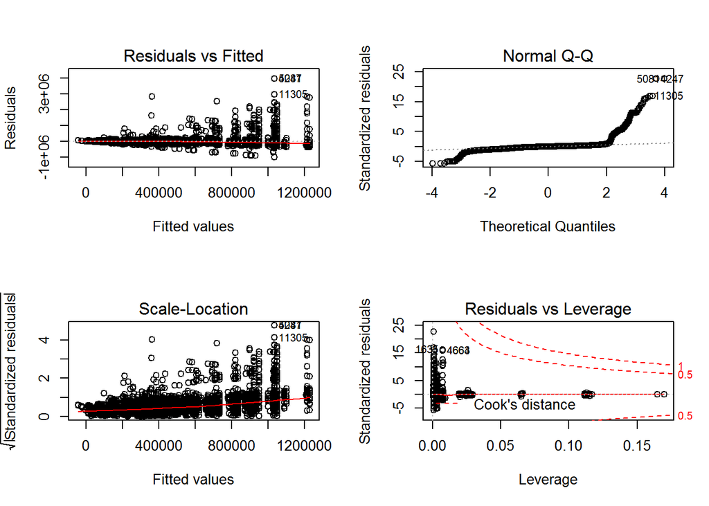

```
##       rstudent unadjusted p-value Bonferonni p
## 4247  23.09646        5.5571e-116  8.2494e-112
## 5081  23.09646        5.5571e-116  8.2494e-112
## 11305 17.13353         3.5380e-65   5.2521e-61
## 13548 17.13353         3.5380e-65   5.2521e-61
## 1635  16.42685         4.1733e-60   6.1953e-56
## 1862  16.40049         6.3924e-60   9.4895e-56
## 4663  16.05053         1.7291e-57   2.5669e-53
## 4664  16.05053         1.7291e-57   2.5669e-53
## 5776  14.66802         2.2551e-48   3.3477e-44
## 4630  14.19924         1.8395e-45   2.7308e-41
```

```
## [1] TRUE
```